# [2] Meningitis: WHO AWaRe QIs analysis against gPPS data

CNPI AMR

Last compiled on Sunday 05 October, 2025

# 📊 Report Overview

This report presents a summary of the AWaRe-based quality indicator analysis based on gPPS inpatient data for Bacterial Meningitis.

This analytical script implements **WHO AWaRe (Access, Watch, Reserve)** antibiotic use **quality indicators (QIs)** for treating **bacterial meningitis** in adult inpatients with **community-acquired infections (CAIs)**. It utilises standardised data from the Global PPS (gPPS), specifically extracted from Excel-based outputs received by participating hospitals.

**Case Definition:**

**Bacterial Meningitis** (Based on WHO AWaRe book)  
▸ **gPPS diagnostic code:** `CNS`  
▸ **gPPS definition:** Includes central nervous system infections

The aim is to assess the appropriateness of **empirical antibiotic prescribing** for meningitis, benchmarked against WHO AWaRe Book, and to provide structured feedback at both the hospital and ward levels. These insights support **antimicrobial stewardship efforts** by highlighting patterns of suboptimal prescribing and identifying opportunities for targeted quality improvement.

## 🎯 WHO AWaRe QIs for Meningitis

Within the scope of the gPPS data structure, **ONE** QI has been identified as compatible for evaluating Meningitis-related empirical antibiotic prescriptions in adults with CAIs:

1. **H_MEN_APPROP_ABX**: Proportion of patients presenting with bacterial meningitis given the appropriate IV antibiotics according to the *WHO AWaRe Book*.

## 💬 General Notes:

- Analysis includes only **adult patients (≥18 years)** with **CAIs** on **empirical** treatment.
- **Intravenous (IV) administration** was inferred using the gPPS `"Route"` code `"P"` (Parenteral), recognizing that it may include other parenteral routes but predominantly indicates IV use in empirical clinical practice.
- It was assumed that **WHO recommendations for bacterial meningitis** align with the gPPS diagnostic code **`CNS` (central nervous system infections)**; therefore, these cases were assessed using the WHO AWaRe classification.
- **QIs** were mapped and interpreted based on clinical assumptions aligning WHO Book with the available **gPPS diagnostic codes**.

💡 **Reminder:** Caution is advised when interpreting results from small sample sizes (<10 patients)

# 🔍 Initial Eligible Cases Check

This section assesses whether there are enough eligible cases to support meaningful analysis.

**📅 Survey period:** 01 Feb 2025 to 05 Feb 2025

This script applies **WHO AWaRe Quality Indicators** to adult inpatients receiving empirical antibiotics for community-acquired bacterial meningitis.

- **Diagnostic code:** CNS
- **Total eligible cases:** 23

**✅ Good to go!** Sufficient eligible cases available to proceed with full evaluation.

# 🧾 Summary of Meningitis Eligible Patients for QI Assessment

Eligible patients for **WHO AWaRe Quality Indicator (QI)** assessment are defined as **adult inpatients (≥18 years)** who received **empirical antibiotics** for **CA-meningitis**.

This section presents both **prescription-level** and **patient-level** summaries to establish how much of the dataset is relevant for QI evaluation. It helps frame the proportion of all prescriptions that are relevant to CA-meningitis.

## 👥 Patient-Level Summary

This table reports on unique patients in each eligibility group. It reflects the clinical burden of meningitis and the proportion of patients suitable for QI evaluation.

**📊 Summary:**  
Total number of patients on antibiotics: **205**  
Total number of eligible patients on antibiotics: **23**

| Patient Category | Number of Patients | Proportion of All Patients |
| --- | --- | --- |
| Number of adult patients (≥18 years) who received empirical antibiotic treatment for CAI | 132 | 64.4% |
| Number of all patients with a diagnosis of meningitis on any antibiotics | 26 | 12.7% |
| **Number of eligible patients:** Adult patients (≥18 years) with a diagnosis of CA-meningitis who were treated empirically with antibiotics | 23 | 11.2% |

## 📑 Prescription-Level Summary

**📊 Summary:**  
Total number of antibiotic prescriptions: **215**  
Total number of eligible antibiotic prescriptions: **23**

| Prescription Category | Number of Prescriptions | Proportion of All Prescriptions |
| --- | --- | --- |
| Number of empirical antibiotic prescriptions administered to adult patients (≥18 years) for CAI | 140 | 65.1% |
| Number of all antibiotic prescriptions for patients diagnosed with meningitis | 26 | 12.1% |
| **Number of eligible antibiotic prescriptions:** antibiotics empirically prescribed for adult patients (≥18 years) with CA-meningitis | 23 | 10.7% |

# 📘 WHO AWaRe-QIs Overview

This section evaluates one indicator:

1. **H_MEN_APPROP_ABX**: Proportion of patients presenting with bacterial meningitis given the appropriate IV antibiotics according to the *WHO AWaRe Book*.

**🔍 WHO AWaRe Book Recommendation:**

**First choice:** Cefotaxime (2 g q6h IV) *OR* Ceftriaxone (2 g q12h IV)  
**Second choice:** Amoxicillin (2 g q4h IV) *OR* Ampicillin (2 g q4h IV) *OR* Benzylpenicillin (4 million IU [2.4 g] q4h IV) *OR* Chloramphenicol (1 g q6h IV)

**📘 WHO AWaRe Notes:**

- Empiric treatment is based on patient age, immune status, and local prevalence of *S. pneumoniae* isolates resistant to third-generation cephalosporins (rare but possible with recent or multiple β-lactam exposures).
- Consider second choice options only when first choice antibiotics are not available.
- Use chloramphenicol only when no other option is available due to its toxicity.
- Add ampicillin (or IV amoxicillin) to ceftriaxone/cefotaxime if risk factors for *Listeria monocytogenes* are present (e.g., age ≥50, pregnancy).
- Due to the severity of meningitis, all suspected cases should be treated immediately as bacterial until viral causes are confirmed or ruled out.
- *Listeria* is not covered by ceftriaxone or cefotaxime—use ampicillin if *Listeria* is suspected.
- Dexamethasone 0.15 mg/kg q6h is recommended only in high-income settings (no evidence of benefit in others).

# 📌 Indicator 1 – IV Antibiotic Appropriateness

> **H_MEN_APPROP_ABX:** Proportion of patients presenting with bacterial meningitis given the appropriate IV antibiotics according to the WHO AWaRe Book.

## 📈 Antibiotic Choice Appropriateness for Meningitis

This visual summarises the proportion of antibiotic appropriateness for meningitis across hospital departments based on WHO AWaRe Book

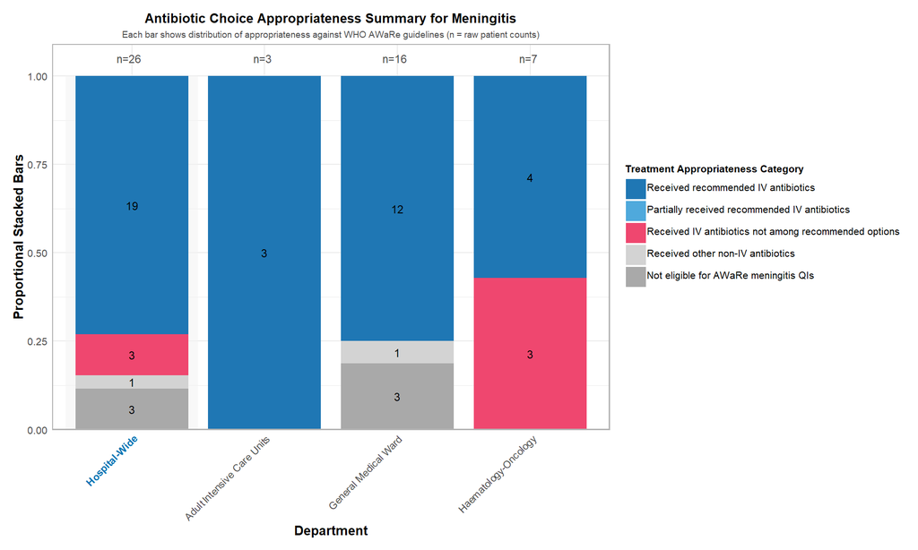

## 📈 Antibiotic Choice Appropriateness by AWaRe Classification

This visual summarises the proportion of antibiotic appropriateness for meningitis across hospital departments by WHO AWaRe Classification (Access, Watch, Reserve)

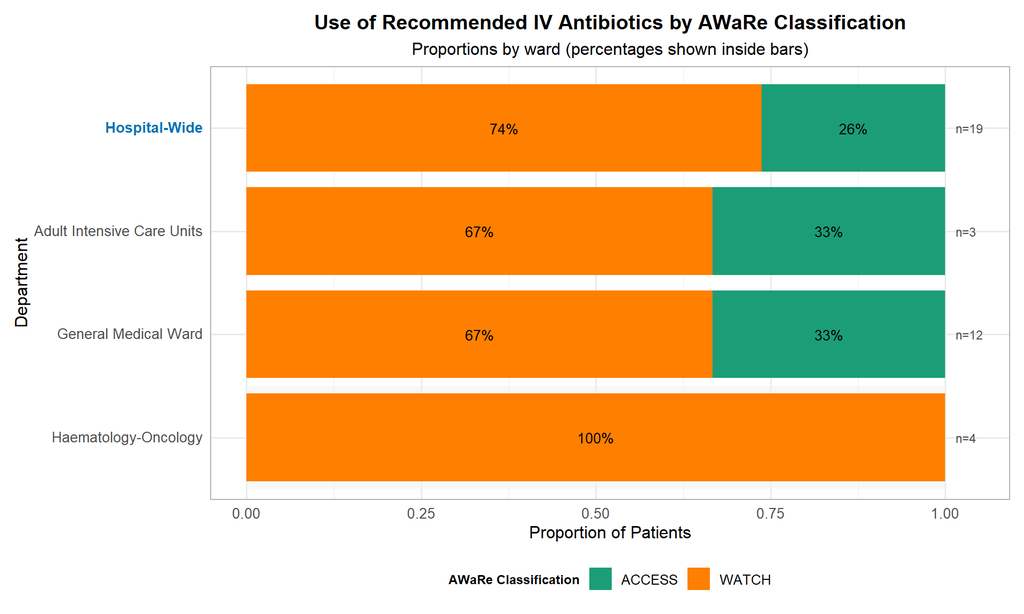

**💡 Note:** The AWaRe classification divides antibiotics into three categories: Access, Watch, and Reserve. Access antibiotics are first-line treatments with a low risk of resistance, typically recommended for common infections. Watch antibiotics are associated with a higher risk of resistance and require careful monitoring. Reserve antibiotics are reserved for critical cases involving resistant infections, typically used only when other options are ineffective .

## 📈 Antibiotic Choice Appropriateness by line of treatment

This visual summarises the proportion of antibiotic appropriateness for meningitis across hospital departments by line of treatment (First choice, Second choice)

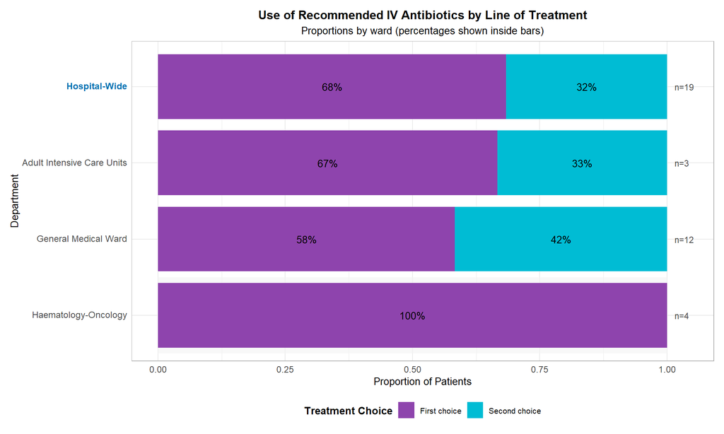

## 📈 Antibiotic Choice Appropriateness for Meningitis

This section summarises the proportion of antibiotic choice appropriateness for meningitis across hospital departments based on the WHO AWaRe Book.

💊 **Denominator:** Number of eligible patients who received any IV antibiotics for meningitis (**22** out of 23).

**Summary:**

**🏥 Hospital-Wide** (n = 22 patients)

- ✅ **Received recommended IV antibiotics** (as per WHO AWaRe Book): **86.4%** (19 out of 22)
- ⚠️ **Partially received recommended IV antibiotics** (as per WHO AWaRe Book): **0.0%** (0 out of 22)
- ❌ **Received IV antibiotics not among recommended options** (as per WHO AWaRe Book): **13.6%** (3 out of 22)

**🏥 Adult Intensive Care Units** (n = 3 patients)

- ✅ **Received recommended IV antibiotics** (as per WHO AWaRe Book): **100.0%** (3 out of 3)
- ⚠️ **Partially received recommended IV antibiotics** (as per WHO AWaRe Book): **0.0%** (0 out of 3)
- ❌ **Received IV antibiotics not among recommended options** (as per WHO AWaRe Book): **0.0%** (0 out of 3)

**🏥 General Medical Ward** (n = 12 patients)

- ✅ **Received recommended IV antibiotics** (as per WHO AWaRe Book): **100.0%** (12 out of 12)
- ⚠️ **Partially received recommended IV antibiotics** (as per WHO AWaRe Book): **0.0%** (0 out of 12)
- ❌ **Received IV antibiotics not among recommended options** (as per WHO AWaRe Book): **0.0%** (0 out of 12)

**🏥 Haematology-Oncology** (n = 7 patients)

- ✅ **Received recommended IV antibiotics** (as per WHO AWaRe Book): **57.1%** (4 out of 7)
- ⚠️ **Partially received recommended IV antibiotics** (as per WHO AWaRe Book): **0.0%** (0 out of 7)
- ❌ **Received IV antibiotics not among recommended options** (as per WHO AWaRe Book): **42.9%** (3 out of 7)

**💡 Note:** The partially recommended category refers to cases in which patients were administered a WHO AWaRe-recommended antibiotic in combination with one or more additional antibiotics, rather than as monotherapy as specified in the guideline.

## 📈 Antibiotic Choice & Dosage Appropriateness for Meningitis

This visual summarises choice & dosage appropriateness for meningitis across hospital departments based on WHO AWaRe Book

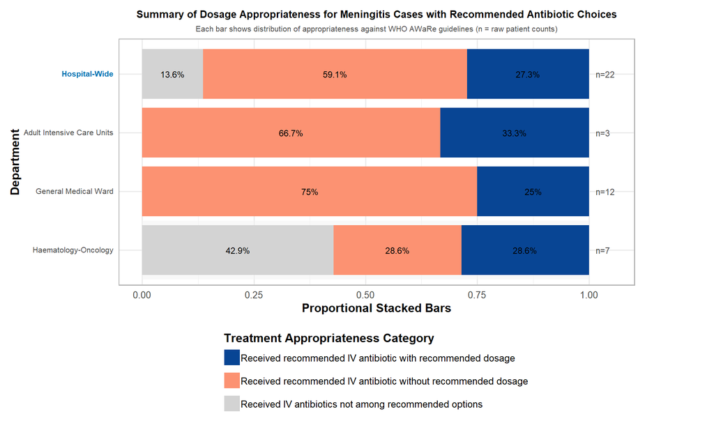

## 📝 Summary of Antibiotic Choice & Dosage Appropriateness for Meningitis

This section evaluates the appropriateness of IV antibiotic drug dosage for patients with meningitis, in line with the WHO AWaRe Book guidance.

💊 **Denominator:** Number of eligible meningitis patients who received any recommended (*or partially recommended*) IV antibiotic choice based on WHO AWaRe Book (**19** out of 23.

**Summary:**

**🏥 Hospital-Wide** (n = 19 patients)

- ✅ **Received recommended IV antibiotic with recommended dosage** (as per WHO AWaRe Book): **31.6%** (6 out of 19)
- ❌ **Received recommended IV antibiotic without recommended dosage** (as per WHO AWaRe Book): **68.4%** (13 out of 19)

**🏥 Adult Intensive Care Units** (n = 3 patients)

- ✅ **Received recommended IV antibiotic with recommended dosage** (as per WHO AWaRe Book): **33.3%** (1 out of 3)
- ❌ **Received recommended IV antibiotic without recommended dosage** (as per WHO AWaRe Book): **66.7%** (2 out of 3)

**🏥 General Medical Ward** (n = 12 patients)

- ✅ **Received recommended IV antibiotic with recommended dosage** (as per WHO AWaRe Book): **25.0%** (3 out of 12)
- ❌ **Received recommended IV antibiotic without recommended dosage** (as per WHO AWaRe Book): **75.0%** (9 out of 12)

**🏥 Haematology-Oncology** (n = 4 patients)

- ✅ **Received recommended IV antibiotic with recommended dosage** (as per WHO AWaRe Book): **50.0%** (2 out of 4)
- ❌ **Received recommended IV antibiotic without recommended dosage** (as per WHO AWaRe Book): **50.0%** (2 out of 4)